# HSC Survey Results

# Scots Bay Survey # 10 Results from 13/09/2026

## Survey Details

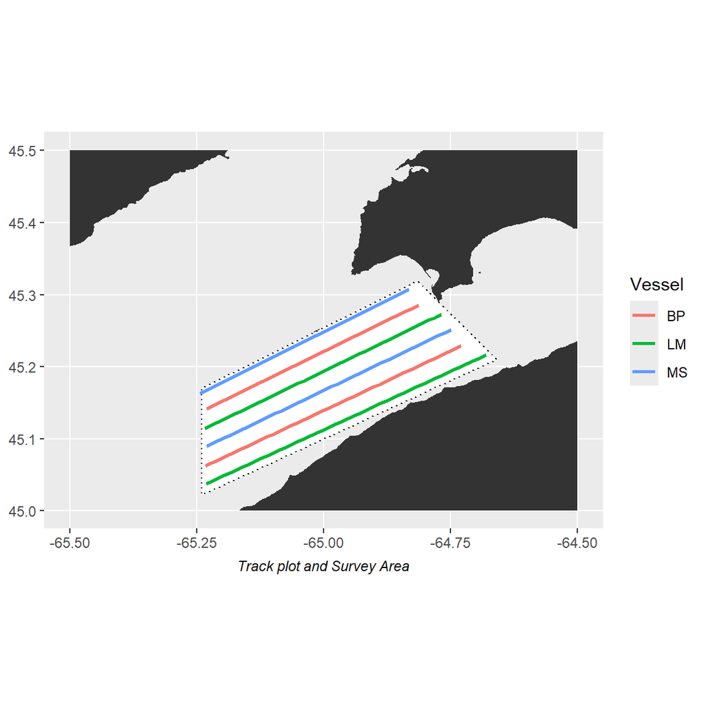

3 commercial purse seiners conducted this fishing survey on 13/09/2026 starting at 19:30:00, which was 5.15 hour after high tide.

All vessels ran two transects each in the Main Survey Box.

There was a plankton tow and replicate conducted and CTD cast by Lady Melissa.

No tags were applied during this survey.

Samples were obtained for target strength estimation.

### Tides Tables

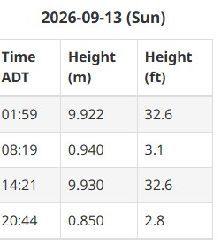

[figure not shown]

Tide Schedule for Margaretsville NS, Station #315m Source: www.waterlevels.gc.ca

### Acoustic Equipment

Each vessel was equipped with a Simrad ES38-18/200-18C combi (2-in-1) transducer prior to the survey that contains a 38kHz split beam and 200 kHz single beam transducer. Data was logged to the computer hard-drive for post-processing. All participating boats were calibrated on 38kHz before the survey.

## Survey Results

### Main Results

The results are subject to change as DFO will re-evaluate data editing, area estimation and apply a target strength.

**Preliminary biomass prediction for Scots Bay using standardized parallel transects is 11,988mt, and with turnover applied 10,451mt.**

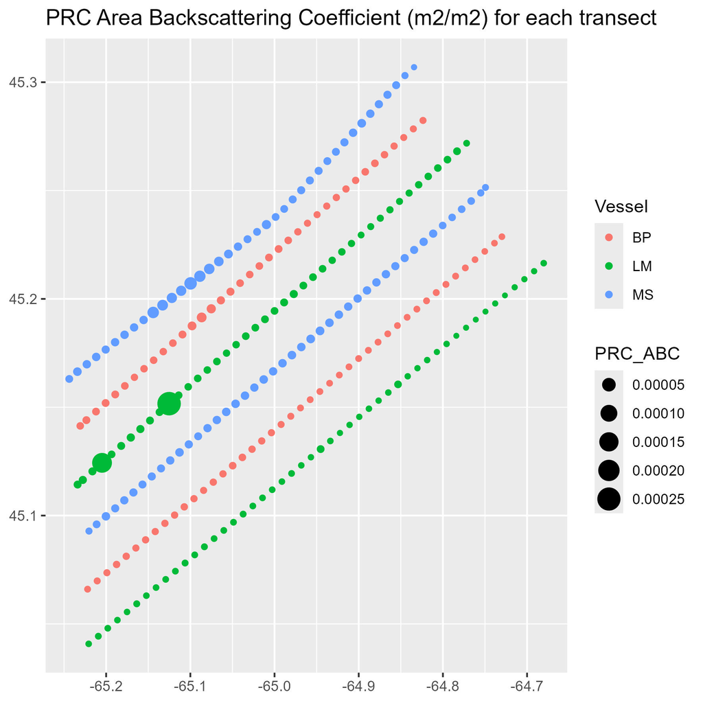

### Transect Details

Table 1: Transect Details

| Vessel | Transect # | Date/Time Start | Date/Time End | Start Lon | Start Lat | End Lon | End Lat | Location | Distance (km) | Speed |
| --- | --- | --- | --- | --- | --- | --- | --- | --- | --- | --- |
| BP | T01 | 2026-09-13 18:28:46 | 2026-09-13 21:16:36 | -65.233 | 45.062 | -64.730 | 45.229 | SB | 43.76 | 8.45 |
| BP | T02 | 2026-09-13 21:50:42 | 2026-09-14 00:09:51 | -64.813 | 45.286 | -65.231 | 45.141 | SB | 36.59 | 8.52 |
| LM | T01 | 2026-09-13 18:56:58 | 2026-09-13 22:02:31 | -65.232 | 45.037 | -64.680 | 45.216 | SB | 47.97 | 8.38 |
| LM | T02 | 2026-09-13 22:37:36 | 2026-09-14 01:18:57 | -64.769 | 45.273 | -65.234 | 45.114 | SB | 40.83 | 8.20 |
| MS | T01 | 2026-09-13 19:45:07 | 2026-09-13 22:39:01 | -65.231 | 45.090 | -64.749 | 45.251 | SB | 43.55 | 8.11 |
| MS | T02 | 2026-09-13 23:24:54 | 2026-09-14 02:06:04 | -64.832 | 45.307 | -65.244 | 45.163 | SB | 38.10 | 7.66 |

### Survey Summary

Table 2: Acoustic Survey Results

| Vessel | Transect No. | Target Strength (db/kg) | Mean Sa (/m2) | Biomass Density (kg/m2) |
| --- | --- | --- | --- | --- |
| LM | T02 | -35.5 | -48.908 | 0.046 |
| MS | T02 | -35.5 | -50.843 | 0.029 |
| MS | T01 | -35.5 | -53.181 | 0.017 |
| BP | T02 | -35.5 | -55.006 | 0.011 |
| BP | T01 | -35.5 | -58.744 | 0.005 |
| LM | T01 | -35.5 | -61.688 | 0.002 |

Note:  
Transects are listed from greatest to least backscatter.

Table 3: Survey Summary Table

| Layer | Target Strength | Area (km2) | Mean Sa | Density (kg/m2) | Biomass (tons) | Percent Area | Percent Biomass | Standard Error (tons) | Standard Error (%) |
| --- | --- | --- | --- | --- | --- | --- | --- | --- | --- |
| Main Box | -35.5 | 675.4278 | -53.0082 | 0.0184 | 11,988.4 | 100 | 100 | 4,537.88 | 37.85 |

### Greatest Biomass Densities

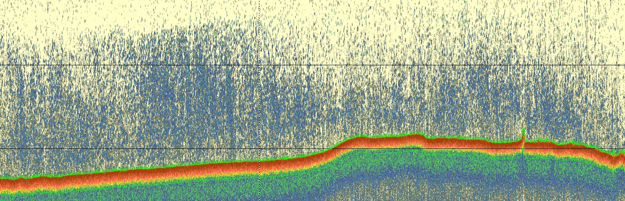

A snip from the transect with the greatest biomass density (kg/m2)

The single point with the largest biomass density (kg/m2) was recorded by **LM**, at the following location:

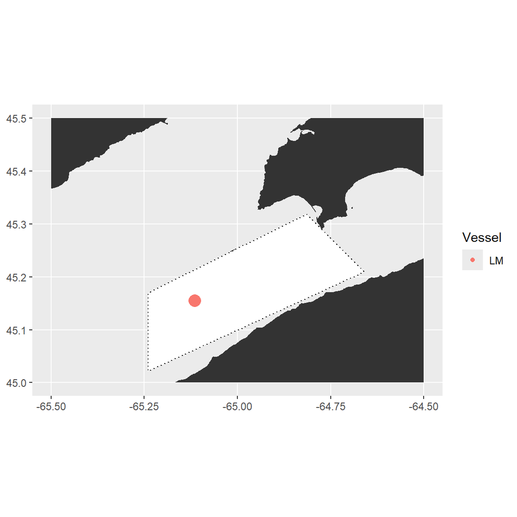

The transect with the greatest average biomass density (kg/m2) was recorded by **LM**, at the following location:

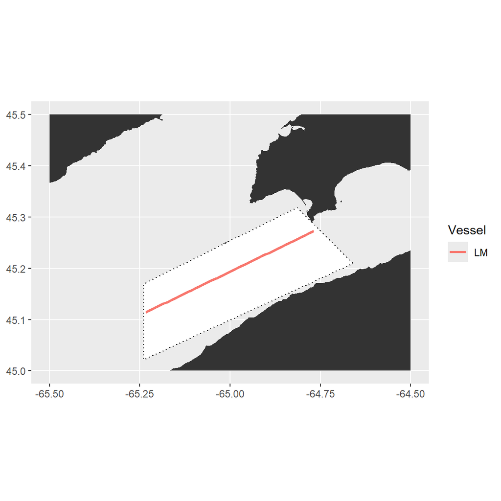

### Annual Summaries

This table does not include the biomass from adhoc surveys.

Table 4: Annual Comparison Table

| Ground | Survey Number | Current Year Survey Date | Current Year HSC Estimate | Current Year HSC Turnover Adjusted | Previous Year Survey Date | Previous Year HSC Estimate | Previous Year HSC Turnover Adjusted | Previous Year DFO Estimate | Previous Year DFO Turnover Adjusted |
| --- | --- | --- | --- | --- | --- | --- | --- | --- | --- |
| Scots Bay | 1 | 2026-05-10 | 29,384.00 | 29,384 | 2025-05-06 | 12,306 | 12,306 | 14,150 | 14,150 |
| Scots Bay | 2 | 2026-05-24 | 61,138.00 | 57,169 | 2025-05-21 | 120,045 | 118,023 | 122,858 | 122,080 |
| Scots Bay | 3 | 2026-06-07 | 48,291.00 | 39,929 | 2025-06-03 | 123,037 | 109,821 | 115,626 | 106,218 |
| Scots Bay | 4 | 2026-06-21 | 44,217.00 | 37,478 | 2025-06-16 | 14,184 | 0 | 8,749 | 0 |
| Scots Bay | 5 | 2026-07-05 | 20,280.02 | 14,137 | 2025-06-30 | 15,789 | 11,509 | 11,651 | 10,539 |
| Scots Bay | 6 | 2026-07-19 | 21,512.88 | 18,616 | 2025-07-14 | 7,114 | 5,137 | 4,287 | 3,532 |
| Scots Bay | 7 | 2026-08-02 | 14,121.98 | 11,144 | 2025-07-28 | 7,573 | 6,612 | 4,465 | 4,145 |
| Scots Bay | 8 | 2026-08-16 | 13,360.10 | 11,377 | 2025-08-11 | 5,164 | 4,916 | 3,831 | 3,537 |
| Scots Bay | 9 | 2026-08-30 | 11,032.83 | 9,178 | 2025-08-26 | 6,675 | 5,948 | 5,032 | 4,821 |
| Scots Bay | 10 | 2026-09-13 | 11,988.40 | 10,451 | 2025-09-08 | 4,180 | 3,169 | 2,246 | 1,845 |
| Scots Bay | 11 | NA | NA | NA | 2025-09-21 | 11,201 | 10,471 | 4,413 | 4,217 |

Table 5: Annual Summary Table

| Year | Ground | HSC Estimate | HSC Turnover Adjusted | DFO Estimate | DFO Turnover Adjusted |
| --- | --- | --- | --- | --- | --- |
| 2025 | Scots Bay | 327,268.0 | 287,912 | 297,308 | 275,084 |
| 2026 | Scots Bay | 275,326.2 | 238,863 | NA | NA |

## Plankton and CTD Data

### Plankton Data

#### Tow Summary Table

|  | Tow 1 | Tow 2 |
| --- | --- | --- |
| **Base Details** |  |  |
| Vessel | Lady Melissa | Lady Melissa |
| Set Number | SB2026-19 | SB2026-20 |
| Ground | SB | SB |
| Date | 13/09/2026 | 13/09/2026 |
| Wind Direction (km/h) | S | S |
| Swell (m) | 0 | 0 |
| Air Temp (c) | 17 | 17 |
| **Tow Details** |  |  |
| Tow Start | 17:59:00 | 18:16:00 |
| Tow End | 18:09:00 | 18:26:00 |
| Start Lat | 45.04917 | 45.04433 |
| End Lat | 45.05483 | 45.03333 |
| Start Lon | -65.22167 | -65.21017 |
| End Lon | -65.20833 | -65.23483 |
| Avg Tow Depth (m) | 7.334022 | 8.040521 |
| Speed | 4.4 | 7.4 |
| Heading | 56 | 236 |
| Tide Direction | against | with |
| **Other Data Collection** |  |  |
| Flow Start | 193214 | 272280 |
| Flow End | 272280 | 326314 |
| No. Revolutions | 79066 | 54034 |
| Distance (m) | 2124.741 | 1452.056 |
| Volume | 6674.873 | 4561.633 |
| Secchi Disappear (m) | 10 | 10 |
| Secchi Reappear (m) | 10 | 10 |

#### Tow Depth Profiles

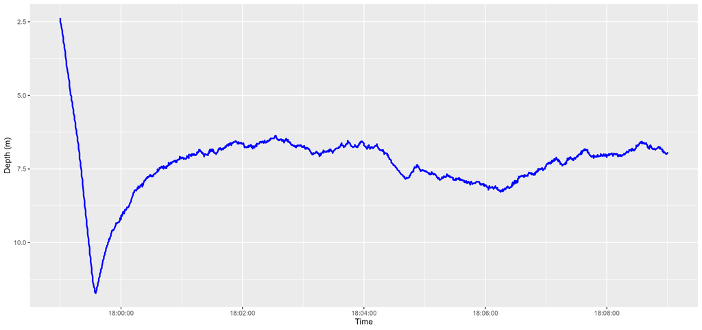

Plankton tow depth profile #1

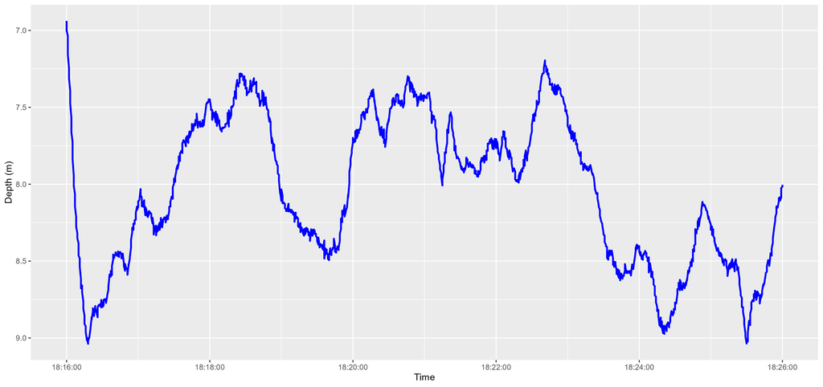

Plankton tow depth profile #2

The first tow is SB2026-19, which was against the tide and had an average depth of 7.334022m. The second tow is SB2026-20, which was with the tide and had an average depth of 8.0405215m.

#### Captured plankton

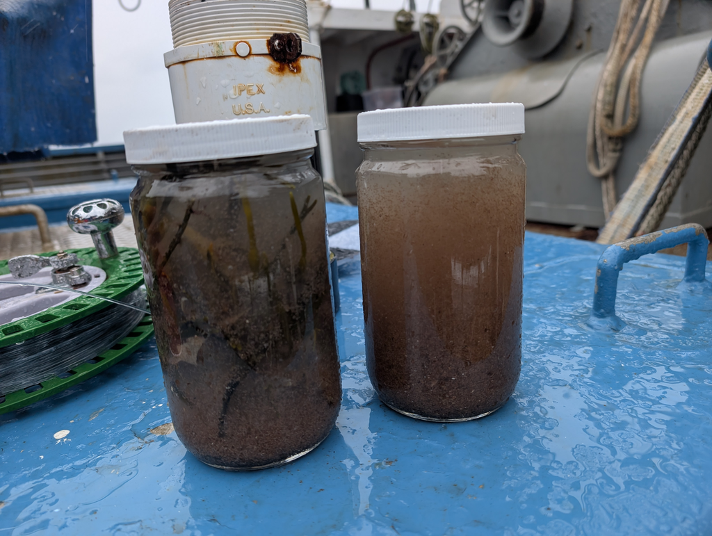

Captured plankton from the surface tows

### CTD Data

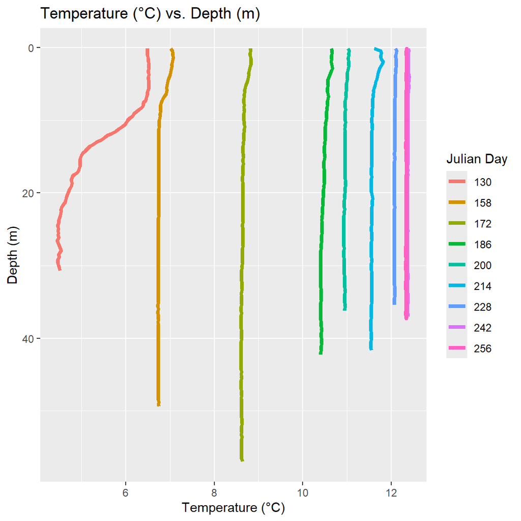

CTD depth profiles for all 2026 Scots Bay surveys so far.

#### Sea surface temperatures

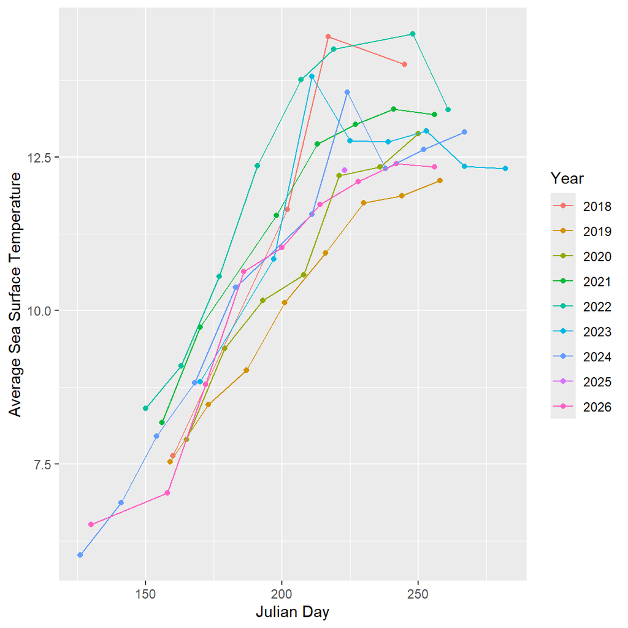

Annual average sea surface temperatures (SST) for Scots Bay.

## Vessel Performance

### Speed

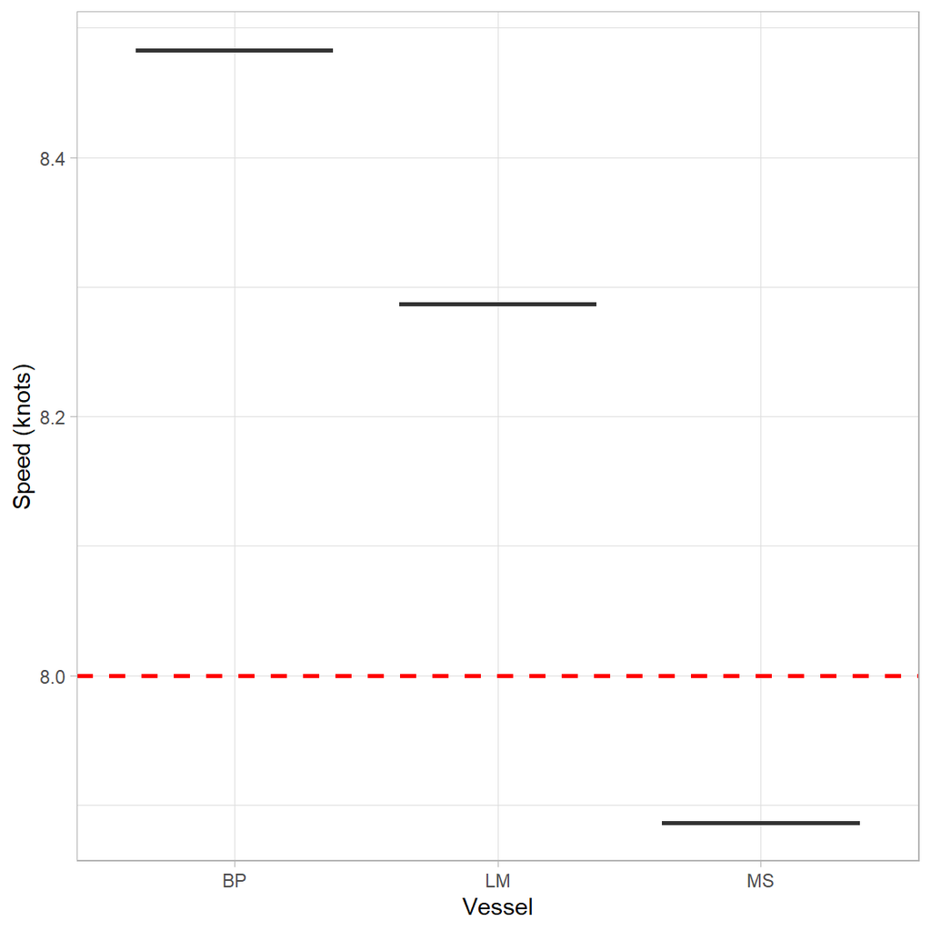

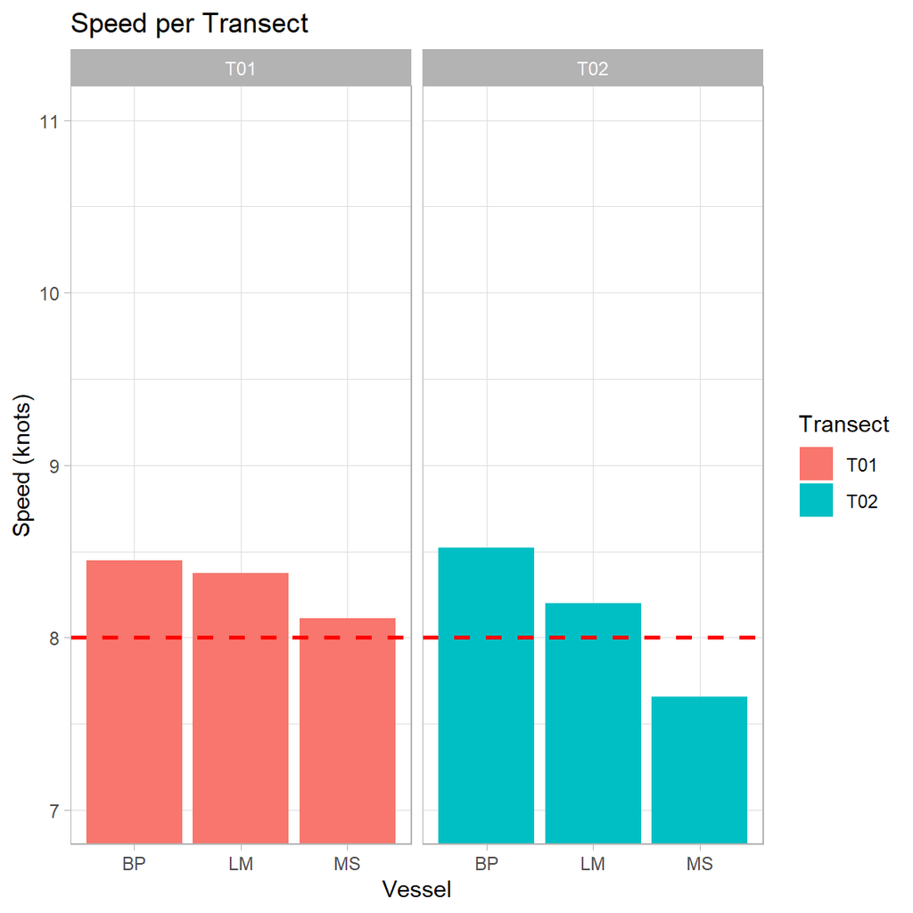

Average vessel speed was 8.22. This is above the 8 knot requirement; vessels are urged to slow down to prevent backscatter noise from interfering with the acoustic data.

The speed for each transect are rudimentary and are calculated based on distance. If a significant amount of distance is cut, the speed will appear slower.